# explanatory_analysis slides

## Bellabeat Marketing Analysis

### by Ifedayo Ayilaran

### Dataset Overview

The data was gathered from 30 users of a smart device prdocued by Bellabeat, a company focused on women's health. Variables include active minutes, sleep hours, total distance, calories and time.

### Which day of the week records the most activity?

Users are mostly active at the beginning of week and Fridays.

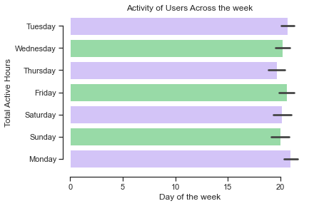

### How often do users log in to the app?

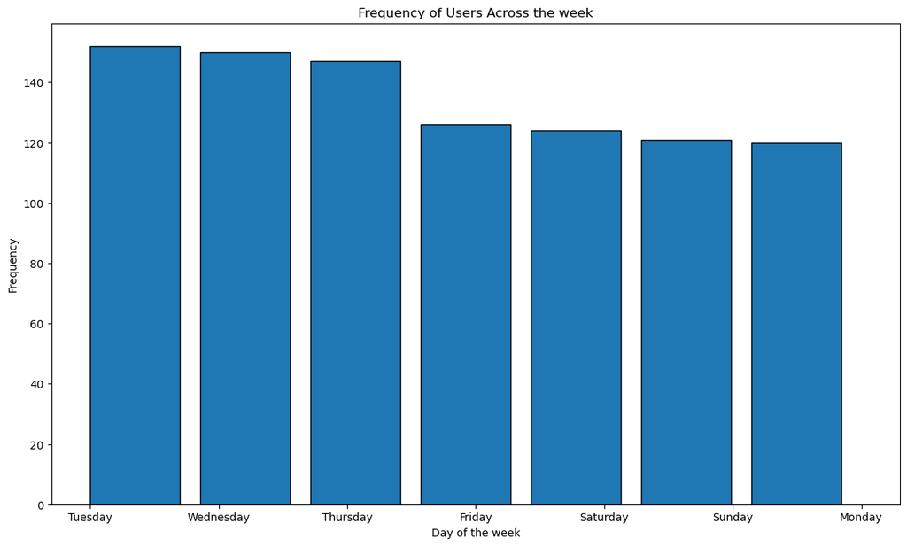

### What's the percentage of Sedentary users?

Sedentary activity accounts for 81% of the total activity in minutes which is a huge chunk of data. It's like that majority of users might not know how to take care of their health. They are not making use of the device to keep track of their fitness goals. ,ost activity tracked with the device is sedentary. In addition to this, since users mostly make use of the device during the week, it suggests that they mainly view it as an accessory or fashion piece.

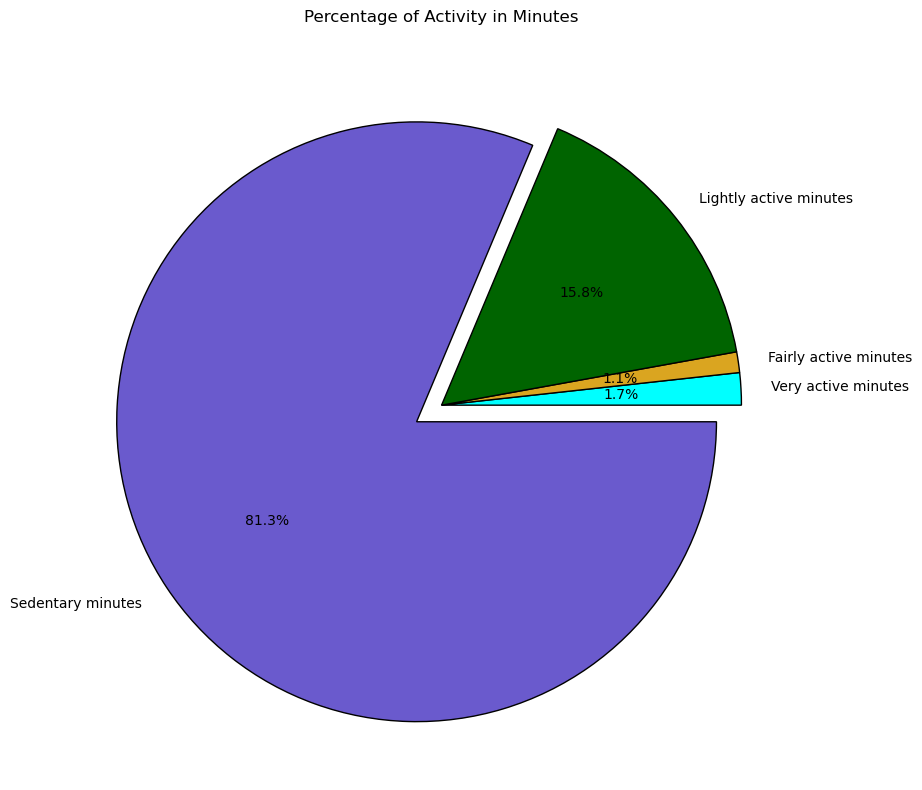

### What distances do users travel most?

Most of the distance tracked by the device is light. This suggests that most users commute short distances, including work and errands. We could create enagement activities targeted at increasing the distance travelled.

|  | index | very_active_distance | moderately_active_distance | light_active_distance | sedentary_active_distance |
| --- | --- | --- | --- | --- | --- |
| 0 | mean | 1.502681 | 0.567543 | 3.340819 | 0.001606 |

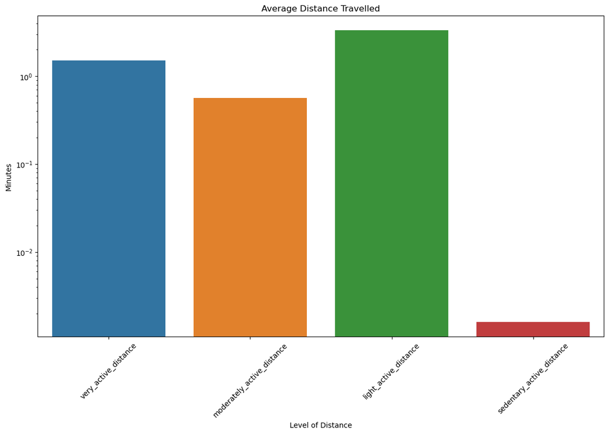

### How does activity affect calories?

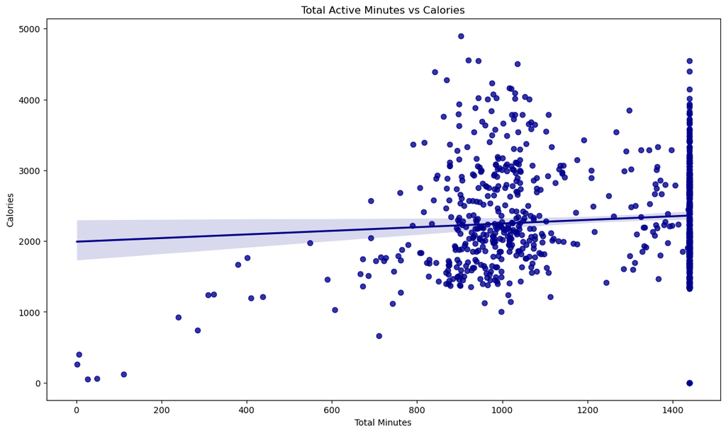

### How many hours do users sleep?

Majority of users sleep for 7 hours, which is normal considering an adult needs 7-8 hours of sleep. Our users are less likely to have trouble sleeping they spend 91% of their time in bed asleep; however, we can pay attention to elping them cultivate a healthy sleeping habit.

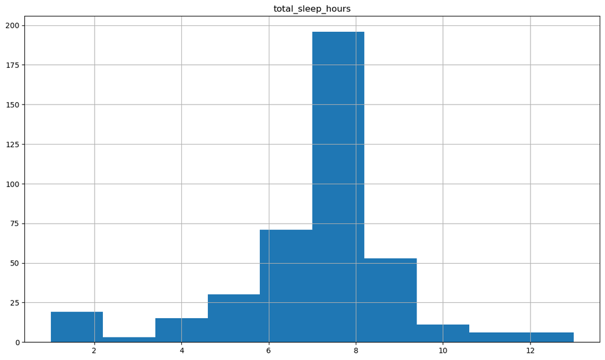

### To position Bellabeat as a solution to women, we need to connect with two things:

1. Help these women understand why they need to take care of their health- with Bellabeat, of course.
2. Make them see Bellabeat as not just an app, but a community of women working on themselves.

### Recommendations to the Marketing Team

- Help the users understand what it means to be fit. Connect them to the benefits of fitness then explain how their activities with our devices can help them reach there. We could send newsletters, organise community events with fitness trainers, and health experts.
- Help them understand how to use the app properly. We could make 'how to' videos to explain the user interface.
- Engage them during weekends. We can create challenges that increase activity during weekends. The activities hsould ideally be light and not tasking to get them familiarised.
- Send reminders whenever the app has been idle.
- To increase distance travelled. and create a bond, we could organize hiking groups during the weekends.
- Organize groups of women and create activities that connect them to the vision of the brand.